# Kevin Durant’s Scoring Legacy in the NBA Playoffs

Gaurav Kumar

6/16/2017

Whether it be fair or unfair, sports media has always had some criticism of Kevin Durant. Coming out of college, they said he was too skinny, so he’d never be able to play in the physical NBA. Then, he became a star, but they said he wasn’t clutch enough, or assertive enough, or mentally strong enough. Once he joined the Golden State Warriors, they called him a coward, a traitor, and a snake.

It isn’t all bad for him though. He’s racked up four scoring titles, been an All-Star eight times, and he won league MVP in 2014. Now, after a dominant run through the playoffs, he’s an NBA champion and a Finals MVP. After averaging 35.2 points per game on 55.6% shooting in the NBA Finals, he has quieted his former critics.

These absurd numbers raise a new question about Durant though. With such a legendary playoff performance on his resume, where does he now rank in the pantheon of all time great postseason scorers?

### Data

I decided to use data from “meaningful” individual playoff runs after the NBA/ABA merger (which occurred in 1976) from http://www.basketball-reference.com. A “meaningful” playoff run occurs when a player averages over 20 points per game in a postseason while also playing at least 8 games. This means that he was one of the top scorers on his team, and the team went to at least the second round of the playoffs.

Setting these barriers allowed me to filter out players who may have averaged huge numbers in a minimal amount of games. There have been plenty of volume scorers on bad teams. I wanted to favor players on winning teams because those are the scorers that will be remembered in history, and effective scoring grows increasingly impressive in later playoff rounds.

One problem, however, is that usage percentage data (which was used in this study) is not available until 1978. Thus, some data from all time great players like Kareem Abdul Jabbar and Julius Erving are not not factored into this analysis.

### Judging Scoring

So, how do we determine how great a scorer is? The two most important aspects of scoring are total output and efficiency. If players shoot endlessly, they are bound to rack up large point totals. But what does this mean if they are missing many shots and hurting their team? That’s why efficiency is important. Similarly, if a player is hitting almost all of his shots but he only shoots a few times a game, how much does that benefit the team? Thus, a combination of both these traits is key in this judgement.

To judge efficiency, we could use true shooting percentage (TS%), but that alone doesn’t account for the amount a player has the ball in his hands. For example, Terry Porter posted a 64.7 TS% in his 1992 playoff run for the Portland Trail Blazers. Though he was an excellent player, he wasn’t tasked with being the engine of his team on the offensive end, as that was Clyde Drexler’s job. On the other hand, Shawn Kemp posted a 64.0 TS% in his 1996 playoff run for the Seattle SuperSonics while being tasked with handling a larger role as undeniably their best player. Therefore, I regressed TS% against usage percentage (USG%) to determine which players posted the highest TS% while also being tasked with handling a larger proportion of his team’s percentage than other players.

```
##
## Call:
## lm(formula = TS. ~ USG., data = totals)
##
## Residuals:
##       Min        1Q    Median        3Q       Max
## -0.100715 -0.032138 -0.001322  0.028457  0.123568
##
## Coefficients:
##               Estimate Std. Error t value Pr(>|t|)
## (Intercept)  0.6251073  0.0166443  37.557  < 2e-16 ***
## USG.        -0.0023207  0.0005937  -3.909 0.000112 ***
## ---
## Signif. codes:  0 '***' 0.001 '**' 0.01 '*' 0.05 '.' 0.1 ' ' 1
##
## Residual standard error: 0.04252 on 332 degrees of freedom
##   (17 observations deleted due to missingness)
## Multiple R-squared:  0.044,  Adjusted R-squared:  0.04112
## F-statistic: 15.28 on 1 and 332 DF,  p-value: 0.0001124
```

We can see that based on the low p-value of this regression, USG% has a statistically significant effect on TS%. This makes sense because they are comprised of some of the same basic statistics. Here is a plot of this linear model against our data:

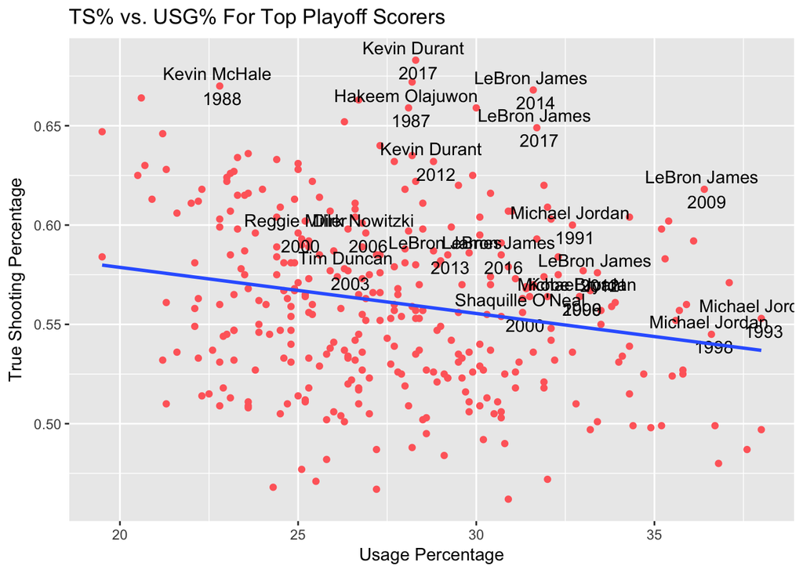

I’ve labeled some points with some of the more memorable individual playoff runs in league history. In many of these significant performances, the player’s TS% was much higher than anticipated based on his USG%. This difference is the hallmark of efficiency, as even relative to other great playoff performers, these players are excelling at scoring. By examining the residual plot of this regression, we can see how Durant favored relative to his esteemed peers in this metric.

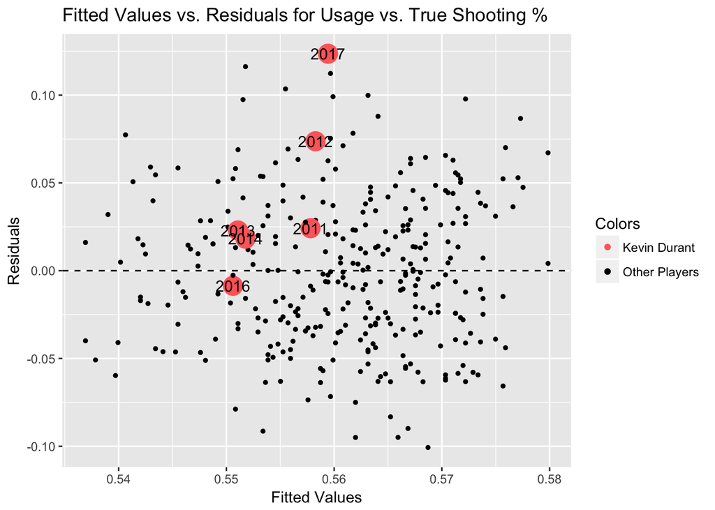

It appears that in a majority of his playoff runs, Durant has been more efficient than his USG% would insinuate. In fact, in the Finals MVP postseason that he just completed, he possesses the all time highest residual. However, one good stretch doesn’t make someone an all time great scorer. Such feats must be completed playoff run after playoff run after playoff run. Thus, I took each player’s residual multiplied by the number of games he played in that postseason and summed those values by player. This gives us a total residual, quantifying total efficiency over the course of one’s playoff career.

Then, I factored in total scoring output. The all time playoff points leaders tend to play many playoff games because their teams win due to their contributions. Thus, scoring output can effectively be measured this way. We can now graph a player’s total efficiency by his total scoring output from these meaningful playoff runs and determine where Durant ranks amongst the all time greats.

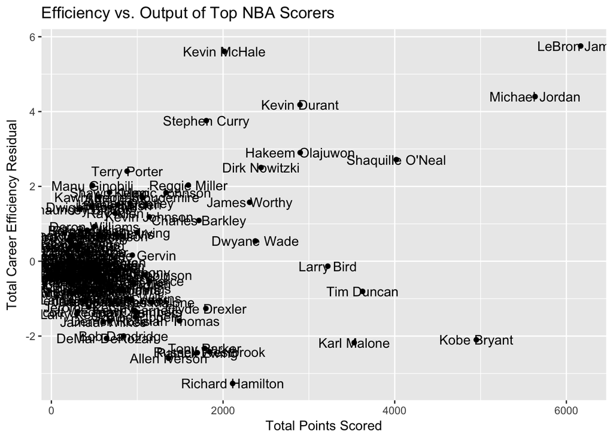

### Conclusions

The names that stand out from the crowd, whether due to total output or supreme efficiency, are commonly thought of as all time greats. Though Kobe Bryant and Karl Malone were not known as the most efficient scorers, the body of work they amassed in these deep playoff runs puts them very high in the ranks. Kevin McHale may not have been the best player on his legendary team, but his world class ability to score in the post puts him in this same conversation. Then, there are LeBron James and Michael Jordan, guys who exhibit both output and efficiency in scoring to the highest degree and are widely thought of as two of the greatest players ever.

Amidst these names, Kevin Durant definitely catches the eye. In terms of efficiency, he’s in the same realm as James, Jordan, and McHale. Those guys along with Durant’s teammate Stephen Curry, Shaquille O’Neal, Hakeem Olajuwon, and Dirk Nowitzki are the most efficient playoff scorers ever according to this metric, and these names do line up with common presumptions.

The team he’s on helps this case, however. Having the floor spaced by guys like Curry and Klay Thompson allows defenses to focus less energy on Durant, so he can capitalize more often on scoring opportunities. Though team play was not factored into this metric well enough (as statistics concerning teamwork are still not fully developed), we still get a good sense for his effectiveness.

When considering output, Durant has excellent numbers, but he still has a ways to go. Legends like O’Neal, Malone, Bryant, Larry Bird, and Tim Duncan still outpace him in this category, and James and Jordan do as well (of course). This isn’t a knock on Durant though. He is right in the prime of his career and has many years left to surpass some of those players’ point totals.

All in all, Durant is now entering some rarified air as a scorer. With the efficiency numbers he’s posted year after year and now an unprecendentedly skilled roster around him, he does not appear to be slowing down at all. By maintaining this efficiency as Golden State continues to make deep playoff runs, Durant has the opportunity to enter the air of Jordan and James (**as a scorer**) when it is all said and done.